# Alex Fields

## BAN 502

### Module 2 - Assignment 2

#### Task 3 - Q&A

When looking at the box plots in figure 3, I noticed how certain variables affected count.Season* - affects count. We can see that this variable is useful in determing when your seasonal peaks and lows will be with your Bikes. It seems that Fall and Summer are your busiest times. Year* - does not affect count (as much as season). This only shows which you the difference quaritle ranges between 2011 and 2012. 2012 had more users on average. *Month* - This is affects count. This is a good variable to have. Like Season, this is a more granular approach to see when you have peaks and lows with users. It seems to line up with Season that May through October you have your peaks. Holiday* - This is not a very good indicator and doesn’t affect count. It shows very little within the Data. Working Day* - This is not a very good indicator and doesn’t affect count. It shows very little within the Data as well like Holiday. Weather* - This seems to be a good indicator for count. This shows if the weather will be affecting users getting bikes. It seems that you have more users on average taking bikes when it is less chance of rain. (Logically that makes sense).

```r
options(tidyverse.quiet = TRUE)

library(tidyverse)
library(GGally)
library(MASS)
library(car)
library(gridExtra)
```

```r
hour <- read_csv("hour.csv")
bike = as_tibble(hour)

bike = bike %>% mutate(season = as_factor(as.character(season))) %>%
mutate(season = fct_recode(season,
"Spring" = "1",
"Summer" = "2",
"Fall" = "3",
"Winter" = "4"))

bike = bike %>% mutate(yr = as_factor(as.character(yr))) %>%
mutate(yr = fct_recode(yr,
"0" = "0",
"1" = "1"))


# We decided to convert yr, mnth and hr variables into factors to convert them to categorical variables.
# These values are not logically quantitative. Even though they are numbers they represent a categorical/string value.
# We should not be running models on "Tuesday".

bike = bike %>% mutate(mnth = as_factor(as.character(mnth))) %>%
mutate(mnth = fct_recode(mnth,
"1" = "1",
"2" = "2",
"3" = "3",
"4" = "4",
"5" = "5",
"6" = "6",
"7" = "7",
"8" = "8",
"9" = "9",
"10" = "10",
"11" = "11",
"12" = "12"))

bike = bike %>% mutate(hr = as_factor(as.character(hr))) %>%
mutate(hr = fct_recode(hr,
"0" = "0",
"1" = "1",
"2" = "2",
"3" = "3",
"4" = "4",
"5" = "5",
"6" = "6",
"7" = "7",
"8" = "8",
"9" = "9",
"10" = "10",
"11" = "11",
"12" = "12",
"13" = "13",
"14" = "14",
"15" = "15",
"16" = "16",
"17" = "17",
"18" = "18",
"19" = "19",
"20" = "20",
"21" = "21",
"22" = "22",
"23" = "23"))

bike = bike %>% mutate(holiday = as_factor(as.character(holiday))) %>%
mutate(holiday = fct_recode(holiday,
"NotHoliday" = "0",
"Holiday" = "1"))

bike = bike %>% mutate(workingday = as_factor(as.character(workingday))) %>%
mutate(workingday = fct_recode(workingday,
"NotWorkingDay" = "0",
"WorkingDay" = "1"))

bike = bike %>% mutate(weathersit = as_factor(as.character(weathersit))) %>%
mutate(weathersit = fct_recode(weathersit,
"NoPrecip" = "1",
"Misty" = "2",
"LightPrecip" = "3",
"HeavyPrecip" = "4"))

bike = bike %>% mutate(weekday = as_factor(as.character(weekday))) %>%
mutate(weekday = fct_recode(weekday,
"Sunday" = "0",
"Monday" = "1",
"Tuesday" = "2",
"Wednesday" = "3",
"Thursday" = "4",
"Friday" = "5",
"Saturday" = "6"))
```

```r
model1 = lm(count ~ temp + atemp + hum + windspeed, bike)#linear model with quantitative variables as dependent        variables, Count being independent vatiable.

summary(model1)
```

```
##
## Call:
## lm(formula = count ~ temp + atemp + hum + windspeed, data = bike)
##
## Residuals:
##     Min      1Q  Median      3Q     Max
## -338.41 -101.49  -33.08   65.18  704.70
##
## Coefficients:
##             Estimate Std. Error t value Pr(>|t|)
## (Intercept)  161.807      6.506  24.872  < 2e-16 ***
## temp          85.576     40.751   2.100   0.0357 *
## atemp        314.343     45.714   6.876 6.35e-12 ***
## hum         -275.180      6.466 -42.560  < 2e-16 ***
## windspeed     42.979     10.451   4.112 3.93e-05 ***
## ---
## Signif. codes:  0 '***' 0.001 '**' 0.01 '*' 0.05 '.' 0.1 ' ' 1
##
## Residual standard error: 156.7 on 17374 degrees of freedom
## Multiple R-squared:  0.2534, Adjusted R-squared:  0.2532
## F-statistic:  1474 on 4 and 17374 DF,  p-value: < 2.2e-16
```

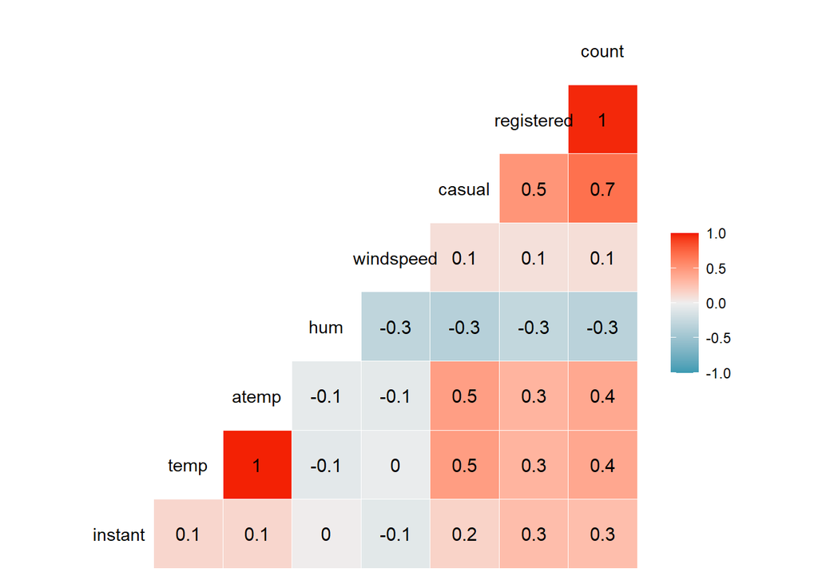

```r
ggcorr(bike, label = TRUE)
```

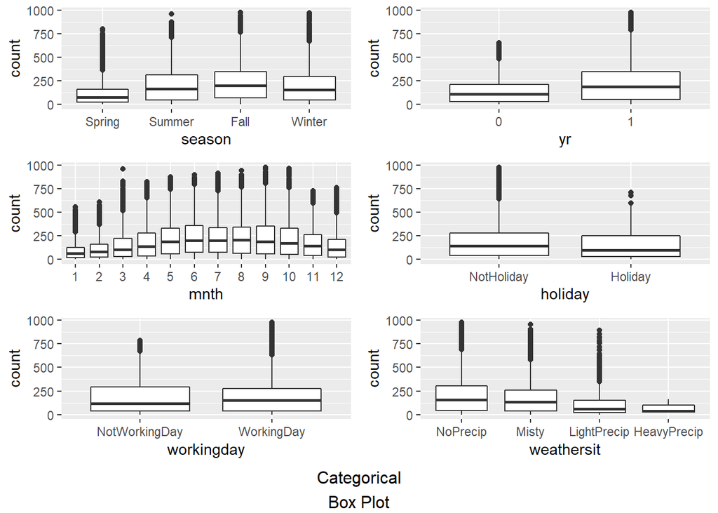

```r
ssn = ggplot(bike, aes(x=season, y=count)) +
  geom_boxplot()

year = ggplot(bike, aes(x=yr, y=count)) +
  geom_boxplot()

month = ggplot(bike, aes(x=mnth, y=count)) +
  geom_boxplot()

hldy = ggplot(bike, aes(x=holiday, y=count)) +
  geom_boxplot()

wkngday = ggplot(bike, aes(x=workingday, y=count)) +
  geom_boxplot()

wethsit = ggplot(bike, aes(x=weathersit, y=count)) +
  geom_boxplot()


grid.arrange(ssn, year, month, hldy, wkngday, wethsit, bottom="Categorical\nBox Plot")
```